# Part I - Project: Investigate Ford GoBike System Dataset

## Introduction

This data set includes information about individual rides made in a bike-sharing system covering the greater San Francisco Bay area.

## Preliminary Wrangling

```python
# import all packages and set plots to be embedded inline
import numpy as np
import pandas as pd
import matplotlib.pyplot as plt
import seaborn as sns

%matplotlib inline
```

```python
#import the Ford GoBike System Data
link='201902-fordgobike-tripdata.csv'
df=pd.read_csv(link)

#print the first five rows of the dataset
df.head()
```

|  | duration_sec | start_time | end_time | start_station_id | start_station_name | start_station_latitude | start_station_longitude | end_station_id | end_station_name | end_station_latitude | end_station_longitude | bike_id | user_type | member_birth_year | member_gender | bike_share_for_all_trip |
| --- | --- | --- | --- | --- | --- | --- | --- | --- | --- | --- | --- | --- | --- | --- | --- | --- |
| 0 | 52185 | 32:10.1 | 01:56.0 | 21.0 | Montgomery St BART Station (Market St at 2nd St) | 37.789625 | -122.400811 | 13.0 | Commercial St at Montgomery St | 37.794231 | -122.402923 | 4902 | Customer | 1984.0 | Male | No |
| 1 | 42521 | 53:21.8 | 42:03.1 | 23.0 | The Embarcadero at Steuart St | 37.791464 | -122.391034 | 81.0 | Berry St at 4th St | 37.775880 | -122.393170 | 2535 | Customer | NaN | NaN | No |
| 2 | 61854 | 13:13.2 | 24:08.1 | 86.0 | Market St at Dolores St | 37.769305 | -122.426826 | 3.0 | Powell St BART Station (Market St at 4th St) | 37.786375 | -122.404904 | 5905 | Customer | 1972.0 | Male | No |
| 3 | 36490 | 54:26.0 | 02:36.8 | 375.0 | Grove St at Masonic Ave | 37.774836 | -122.446546 | 70.0 | Central Ave at Fell St | 37.773311 | -122.444293 | 6638 | Subscriber | 1989.0 | Other | No |
| 4 | 1585 | 54:18.5 | 20:44.1 | 7.0 | Frank H Ogawa Plaza | 37.804562 | -122.271738 | 222.0 | 10th Ave at E 15th St | 37.792714 | -122.248780 | 4898 | Subscriber | 1974.0 | Male | Yes |

## Check for the summary of the data

```python
#check for the columns and row
print(df.shape)

#check for the dataset's datatypes
df.info()
```

```
(65819, 16)
<class 'pandas.core.frame.DataFrame'>
RangeIndex: 65819 entries, 0 to 65818
Data columns (total 16 columns):
duration_sec               65819 non-null int64
start_time                 65819 non-null object
end_time                   65819 non-null object
start_station_id           65729 non-null float64
start_station_name         65729 non-null object
start_station_latitude     65819 non-null float64
start_station_longitude    65819 non-null float64
end_station_id             65729 non-null float64
end_station_name           65729 non-null object
end_station_latitude       65819 non-null float64
end_station_longitude      65819 non-null float64
bike_id                    65819 non-null int64
user_type                  65819 non-null object
member_birth_year          63018 non-null float64
member_gender              63018 non-null object
bike_share_for_all_trip    65819 non-null object
dtypes: float64(7), int64(2), object(7)
memory usage: 8.0+ MB
```

```python
# descriptive statistics for numeric variables
df.describe()
```

|  | duration_sec | start_station_id | start_station_latitude | start_station_longitude | end_station_id | end_station_latitude | end_station_longitude | bike_id | member_birth_year |
| --- | --- | --- | --- | --- | --- | --- | --- | --- | --- |
| count | 65819.000000 | 65729.000000 | 65819.000000 | 65819.000000 | 65729.000000 | 65819.000000 | 65819.000000 | 65819.000000 | 63018.000000 |
| mean | 726.077941 | 138.381217 | 37.771171 | -122.353460 | 136.288609 | 37.771375 | -122.353112 | 4860.433537 | 1984.750754 |
| std | 1668.704531 | 112.512516 | 0.099395 | 0.116900 | 112.226266 | 0.099314 | 0.116564 | 1589.807715 | 10.249640 |
| min | 61.000000 | 3.000000 | 37.317298 | -122.453704 | 3.000000 | 37.317298 | -122.453704 | 11.000000 | 1878.000000 |
| 25% | 327.000000 | 46.000000 | 37.770407 | -122.412544 | 44.000000 | 37.770407 | -122.411738 | 4525.000000 | 1980.000000 |
| 50% | 519.000000 | 101.000000 | 37.780760 | -122.398436 | 99.000000 | 37.780955 | -122.398285 | 5255.000000 | 1987.000000 |
| 75% | 806.000000 | 239.000000 | 37.797280 | -122.289370 | 238.000000 | 37.797280 | -122.290230 | 6030.000000 | 1992.000000 |
| max | 83195.000000 | 398.000000 | 37.880222 | -121.874119 | 398.000000 | 37.880222 | -121.874119 | 6644.000000 | 2001.000000 |

### What is/are the main feature(s) of interest in your dataset?

> I'm most interested in figuring out what features are best for predicting the duration of bike rides in the dataset.

### What features in the dataset do you think will help support your investigation into your feature(s) of interest?

> I expect that riders' age will have a great effect on the riders' durations. I also think that members' gender and user type will play a big part in the length of their bike rides.

## Univariate Exploration

### Data cleaning

```python
df.isnull().sum()
```

```
duration_sec                  0
start_time                    0
end_time                      0
start_station_id             90
start_station_name           90
start_station_latitude        0
start_station_longitude       0
end_station_id               90
end_station_name             90
end_station_latitude          0
end_station_longitude         0
bike_id                       0
user_type                     0
member_birth_year          2801
member_gender              2801
bike_share_for_all_trip       0
dtype: int64
```

```python
#drop rows with missing data
df.dropna(inplace=True)
```

```python
#Check for duplicates
df.duplicated().sum()
```

```
0
```

### Feature Engineering

```python
#convert seconds to minutes for easier interpretation of the data
df['duration_min']=df['duration_sec']/60
df['duration_min']=df['duration_min'].round(2)
df.head()
```

|  | duration_sec | start_time | end_time | start_station_id | start_station_name | start_station_latitude | start_station_longitude | end_station_id | end_station_name | end_station_latitude | end_station_longitude | bike_id | user_type | member_birth_year | member_gender | bike_share_for_all_trip | duration_min |
| --- | --- | --- | --- | --- | --- | --- | --- | --- | --- | --- | --- | --- | --- | --- | --- | --- | --- |
| 0 | 52185 | 32:10.1 | 01:56.0 | 21.0 | Montgomery St BART Station (Market St at 2nd St) | 37.789625 | -122.400811 | 13.0 | Commercial St at Montgomery St | 37.794231 | -122.402923 | 4902 | Customer | 1984.0 | Male | No | 869.75 |
| 2 | 61854 | 13:13.2 | 24:08.1 | 86.0 | Market St at Dolores St | 37.769305 | -122.426826 | 3.0 | Powell St BART Station (Market St at 4th St) | 37.786375 | -122.404904 | 5905 | Customer | 1972.0 | Male | No | 1030.90 |
| 3 | 36490 | 54:26.0 | 02:36.8 | 375.0 | Grove St at Masonic Ave | 37.774836 | -122.446546 | 70.0 | Central Ave at Fell St | 37.773311 | -122.444293 | 6638 | Subscriber | 1989.0 | Other | No | 608.17 |
| 4 | 1585 | 54:18.5 | 20:44.1 | 7.0 | Frank H Ogawa Plaza | 37.804562 | -122.271738 | 222.0 | 10th Ave at E 15th St | 37.792714 | -122.248780 | 4898 | Subscriber | 1974.0 | Male | Yes | 26.42 |
| 5 | 1793 | 49:58.6 | 19:51.8 | 93.0 | 4th St at Mission Bay Blvd S | 37.770407 | -122.391198 | 323.0 | Broadway at Kearny | 37.798014 | -122.405950 | 5200 | Subscriber | 1959.0 | Male | No | 29.88 |

```python
#calculate the age of the riders
#Note-This data set was obtained in 2019 hence the age was calculated to reflect their ages at that time.
df['member_age']=2019-df['member_birth_year']
df['member_age']=df['member_age'].astype(int)
df.head()
```

|  | duration_sec | start_time | end_time | start_station_id | start_station_name | start_station_latitude | start_station_longitude | end_station_id | end_station_name | end_station_latitude | end_station_longitude | bike_id | user_type | member_birth_year | member_gender | bike_share_for_all_trip | duration_min | member_age |
| --- | --- | --- | --- | --- | --- | --- | --- | --- | --- | --- | --- | --- | --- | --- | --- | --- | --- | --- |
| 0 | 52185 | 32:10.1 | 01:56.0 | 21.0 | Montgomery St BART Station (Market St at 2nd St) | 37.789625 | -122.400811 | 13.0 | Commercial St at Montgomery St | 37.794231 | -122.402923 | 4902 | Customer | 1984.0 | Male | No | 869.75 | 35 |
| 2 | 61854 | 13:13.2 | 24:08.1 | 86.0 | Market St at Dolores St | 37.769305 | -122.426826 | 3.0 | Powell St BART Station (Market St at 4th St) | 37.786375 | -122.404904 | 5905 | Customer | 1972.0 | Male | No | 1030.90 | 47 |
| 3 | 36490 | 54:26.0 | 02:36.8 | 375.0 | Grove St at Masonic Ave | 37.774836 | -122.446546 | 70.0 | Central Ave at Fell St | 37.773311 | -122.444293 | 6638 | Subscriber | 1989.0 | Other | No | 608.17 | 30 |
| 4 | 1585 | 54:18.5 | 20:44.1 | 7.0 | Frank H Ogawa Plaza | 37.804562 | -122.271738 | 222.0 | 10th Ave at E 15th St | 37.792714 | -122.248780 | 4898 | Subscriber | 1974.0 | Male | Yes | 26.42 | 45 |
| 5 | 1793 | 49:58.6 | 19:51.8 | 93.0 | 4th St at Mission Bay Blvd S | 37.770407 | -122.391198 | 323.0 | Broadway at Kearny | 37.798014 | -122.405950 | 5200 | Subscriber | 1959.0 | Male | No | 29.88 | 60 |

### Plot the distribution for duration_min

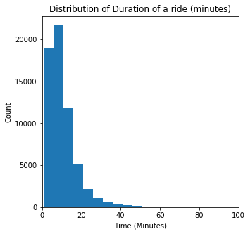

```python
plt.figure(figsize=[5, 5])
bins_edges=np.arange(df['duration_min'].min(), df['duration_min'].max()+5, 5)
plt.hist(data=df, x='duration_min', bins=bins_edges)
plt.title('Distribution of Duration of a ride (minutes)')
plt.xlabel('Time (Minutes)')
plt.ylabel('Count')
plt.xlim((0, 100));
```

```python
#check for data that's above 100 minutes
i=df[df['duration_min']>100]
print(i.shape)
```

```
(276, 18)
```

```python
#remove outliers from the data set ie duration_min that is above 100 minutes
df=df[df['duration_min']<100]
df.shape
```

```
(62654, 18)
```

> The duration distribution is skewed to the right, let use's the log scale instead and see if the trend will change.

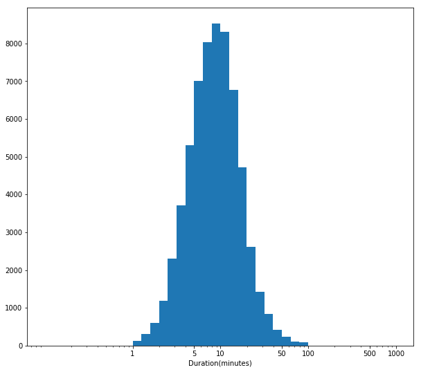

```python
plt.figure(figsize=[10, 9])
#Get the ticks for bins between 0 and the maximum dutation
bins = 10 ** np.arange(-1, 3+0.1, 0.1)

# Generate the x-ticks for the graph
ticks = [1, 5, 10, 50, 100, 500, 1000]
# Convert ticks into string values and to be displayed on the X axis
labels = ['{}'.format(v) for v in ticks]

# Plot the histogram
plt.hist(data=df, x='duration_min', bins=bins);
#transform X-axis to a log scale
plt.xscale('log')
plt.xlabel('Duration(minutes)')

# Apply x-ticks
plt.xticks(ticks, labels);
```

> The distribution of the time taken to ride a bike is unimodal, peaking between 8-10 minutes.

### Age distribution

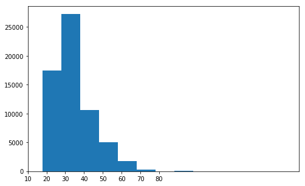

```python
plt.figure(figsize=[8, 5])
x_ticks=[10, 20, 30, 40, 50, 60, 70, 80]
bin_size=10
bins=np.arange(df['member_age'].min(), df['member_age'].max()+bin_size, bin_size)
plt.hist(data=df, x='member_age', bins=bins)
plt.xticks(x_ticks);
```

```python
#check for outliers using member's age
i=df[df['member_age']>80]
print(i.shape)

#remove outliers using member_age
df=df[df['member_age']<80]
```

```
(93, 18)
```

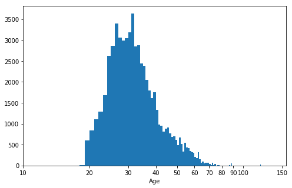

```python
plt.figure(figsize=[8, 5])
# Generate the x-ticks you want to apply

# Generate the x-ticks for the graph
ticks = [10, 20, 30, 40, 50, 60, 70, 80, 90, 100, 150]
# Convert ticks into string values and to be displayed on the X axis
labels = ['{}'.format(v) for v in ticks]

bin_size=1
bins=np.arange(df['member_age'].min(), df['member_age'].max()+bin_size, bin_size)
plt.hist(data=df, x='member_age', bins=bins)
plt.xscale('log')
plt.xlabel('Age')
# Apply x-ticks
plt.xticks(ticks, labels);
```

### Categorical variables univariate Exploration

```python
#creat function for count plot
def count_plot(x_var):
    plt.figure(figsize=[8, 5])
    base_color = sns.color_palette()[0]
    sns.countplot(data = df, x = x_var, color = base_color)
    plt.yticks([0, 10000, 20000, 30000, 40000, 50000],[0, '10k', '20k', '30k', '40k','50k'])
```

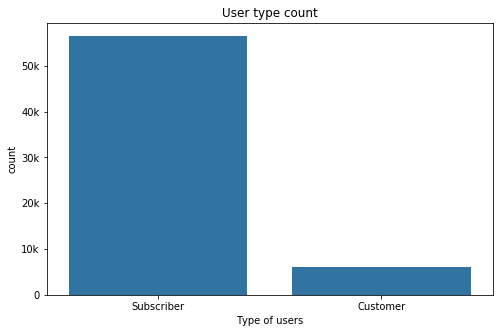

```python
#plot count for user type

ax=count_plot('user_type')
ax=plt.xlabel('Type of users')
ax=plt.title('User type count')
```

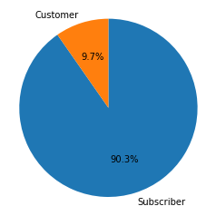

```python
#plot a pie plot for easier comparison
users = df['user_type'].value_counts()
plt.pie(users, labels = users.index, startangle = 90, counterclock = False, autopct='%1.1f%%');
plt.axis('square')
plt.show()
```

> 90.3% of the overall riders were from subscribers.

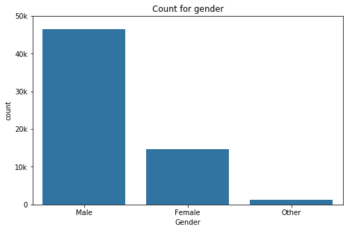

```python
gen=count_plot('member_gender')
plt.xlabel('Gender')
plt.title('Count for gender');
```

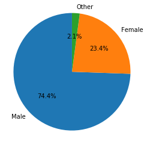

```python
gen = df['member_gender'].value_counts()
plt.pie(gen, labels = gen.index, startangle = 90, counterclock = True, autopct='%1.1f%%');
plt.axis('square')
plt.show()
```

> Males make up for 74.4% of the overall rides which is a pretty high number.

### Discuss the distribution(s) of your variable(s) of interest. Were there any unusual points? Did you need to perform any transformations?

> The duration_min data was skewed to the right hence I transformed the X axis using logarithimic function. After the transformation, it showed the data had a normal distribution with the peak at 8-10 minutes. I also perfromed a log transformation on the age distribution histogram.

### Of the features you investigated, were there any unusual distributions? Did you perform any operations on the data to tidy, adjust, or change the form of the data? If so, why did you do this?

> - First, I changed the duration from seconds to minutes by dividing it by 60 for easier interpretation because we are used to working with minutes. The outliers detected on the histogram were removed.
> - Second, I calculated the age of members using the member_birth_year data because I wanted to use age in my analysis. The data was obtained in 2019 hence this was the Year used in the calculation.
> - Third, after obtaining the age I noticed there were some outliers on the data, ie several people above 100 year old, and since this data is about bike riding, this doesn't seem practical and hence the outliers were removed.

## Bivariate Exploration

### Check the relationship between duration_min and member_age

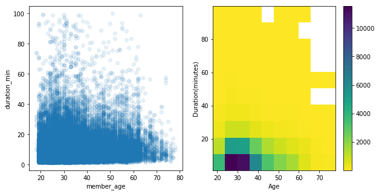

```python
#plot a scatter plot
plt.figure(figsize=[10, 5])

plt.subplot(1, 2, 1)
sns.regplot(data=df, x='member_age', y='duration_min', x_jitter=0.04, scatter_kws={'alpha':1/10}, fit_reg=False)

plt.subplot(1, 2, 2)
plt.hist2d(data=df, x='member_age', y='duration_min', cmin=0.5, cmap='viridis_r')
plt.xlabel('Age')
plt.ylabel('Duration(minutes)')
plt.colorbar() ;
```

> By looking at the heatmap, it can be noted that most frequent riders are aged between 25 and 40. There is also an inverse relationship between duration of a ride and age of a rider, ie the younger a rider is the longer the trip. Older riders tend to have shorter trips.

### Bivariate Exploration of categorical variables

```python
#create a function for ploting a violinplot and a box plot to visualize one quantitative and one qualitative variable
def sub_plot (x_axis, y_axis):
    base_color = sns.color_palette()[0]
    plt.figure(figsize=[8, 5])
    plt.subplot(1, 2, 1)
    sns.violinplot(x_axis, y_axis, data=df, color=base_color, inner=None)
    plt.subplot(1, 2, 2)
    sns.boxplot(x_axis, y_axis, data=df, color=base_color)
```

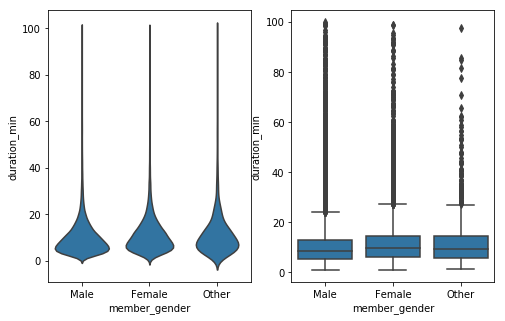

```python
#plot Member gender VS the duration_min
sub_plot('member_gender', 'duration_min')
```

> From the above plots it can be noted that male riders take shorter trips as compared to females and other genders.

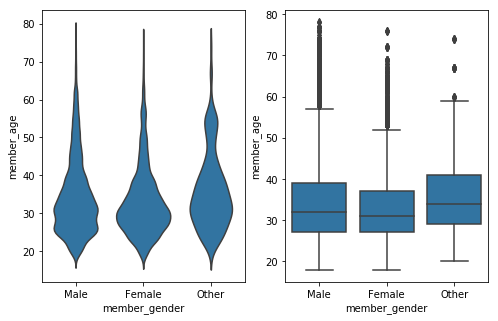

```python
#Plot member gender VS Member_age
sub_plot('member_gender', 'member_age')
```

> It is interesting to note that males and other genders have a wider age distribution compared to females. Also, other gender rider's have an older age distribution compared to males and females.

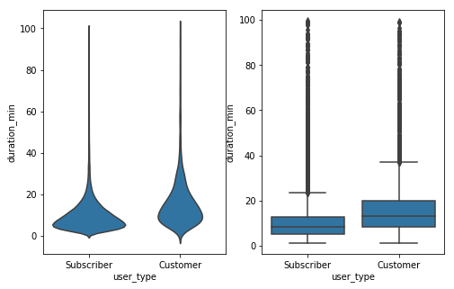

```python
#plot a violinplot and boxplot for user_type VS duration_min
sub_plot('user_type', 'duration_min')
```

> It can be noted that customers are taking longer trips as compared to subscribers

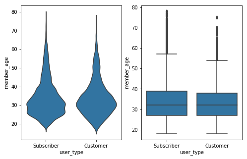

```python
#plot user_type vs member_age
sub_plot('user_type', 'member_age')
```

> From the above plot we can note that subscribers have a wider age distribution as compared to customers

### Relationship between the categorical variables

```python
#create a function for count plots
def count_plot(x_axis, hue):
    sns.countplot( x=x_axis, hue=hue, data = df,)
    ticks=[0, 5000, 10000, 15000, 20000, 25000, 30000, 35000, 40000]
    plt.yticks(ticks,[0, '5k', '10k', '15k', '20k', '25k', '30k', '35k', '40k'])
```

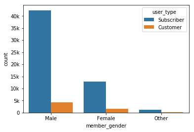

```python
count_plot('member_gender', 'user_type')
```

> Males make up for most rides recorded. Also all genders prefer having a subscription.

### Did you observe any interesting relationships between the other features (not the main feature(s) of interest)?

> I expected the subsribers to have longer trips but customers were the ones with longer durations. Also, I expected the frequency of rides to be almost evenly distributed among the genders but the males' counts was much highers compared to the rest.

## Multivariate Exploration

> I will be investigating how gender, user type and age affect the duration a rider takes.

#### Relationship between age, duration and gender

```python
#Create a function for facetGrid
def g(x):
    g = sns.FacetGrid(data = df, hue = x, size = 5)
    g.map(plt.scatter, 'member_age', 'duration_min')
    plt.legend(loc='upper right');
```

```python
def fg(x):
    g = sns.FacetGrid(data = df, col = x, size = 5, margin_titles = True)
    g.map(plt.scatter, 'member_age', 'duration_min', alpha=0.25)
```

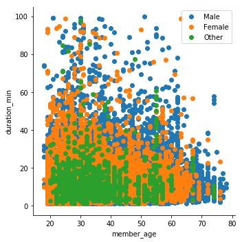

```python
gender=g('member_gender')
```

Lets create a much more clearer graph

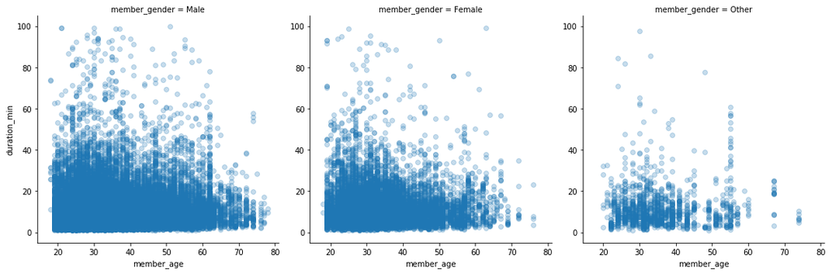

```python
fg('member_gender')
```

> It can be noted that riders from the age of 70-80 take shorter trips across all genders and they are fewer.

#### Relationship between age, duration and user type

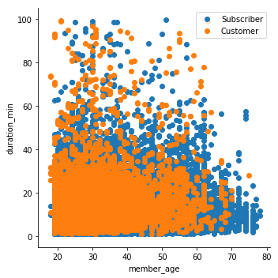

```python
user=g('user_type')
```

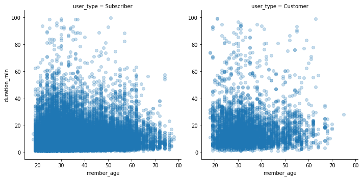

```python
fg('user_type')
```

> Both subscribers and customers have a similar trend in terms of members age and duration of a trip.

### Talk about some of the relationships you observed in this part of the investigation. Were there features that strengthened each other in terms of looking at your feature(s) of interest?

> Riders from the age of 70-80 take shorter trips across all genders and they are fewer.

### Were there any interesting or surprising interactions between features?

> Customers are concentrated below the age of 70, very few data sets can be spotted above 70 years old. There is a high concentration of riders for other genders between the ages of 56-57.